# Homework 12 Solutions

Farouk Alghazzy

## Problem #1. Guided k-fold CV exercise 9pts

In this exercise, we will guide you through an exercise where you are asked to use k-fold cross validation to evaluate the performance of several models.

For this exercise we will use the “Swiss Fertility and Socioeconomic Indicators (1888)” dataset from the `datasets` package, which is loaded below. (To view the help page, run `?datasets::swiss` in your console). We will be using `Fertility` as our response variable.

```r
swiss = datasets::swiss
```

### Part a) Understanding/visualizing data

Read the help page and briefly “introduce” this dataset. Specifically, explain where the data comes from, what variables it contains, and why should people care about the dataset.

Produce one or some visualizations of the data. Do your best here to try to use your plots to help your viewer best understand the structure and patterns of this dataset. Choose your plots carefully and briefly explain what each plot tells you about the data.

```r
# In this exercise, we will use K-fold cross-validation to evaluate the performance of multiple linear regression models applied to the Swiss Fertility and Socioeconomic Indicators (1888) dataset. This dataset contains standardized fertility measures and several socioeconomic variables for 47 French-speaking provinces of Switzerland from 1888. Our goal is to model Fertility as the response variable, using different combinations of predictors to determine which model performs best in terms of prediction error.
```

```r
library(ggplot2)
data("swiss")
str(swiss)
```

```
## 'data.frame':    47 obs. of  6 variables:
##  $ Fertility       : num  80.2 83.1 92.5 85.8 76.9 76.1 83.8 92.4 82.4 82.9 ...
##  $ Agriculture     : num  17 45.1 39.7 36.5 43.5 35.3 70.2 67.8 53.3 45.2 ...
##  $ Examination     : int  15 6 5 12 17 9 16 14 12 16 ...
##  $ Education       : int  12 9 5 7 15 7 7 8 7 13 ...
##  $ Catholic        : num  9.96 84.84 93.4 33.77 5.16 ...
##  $ Infant.Mortality: num  22.2 22.2 20.2 20.3 20.6 26.6 23.6 24.9 21 24.4 ...
```

```r
summary(swiss)
```

```
##    Fertility      Agriculture     Examination      Education
##  Min.   :35.00   Min.   : 1.20   Min.   : 3.00   Min.   : 1.00
##  1st Qu.:64.70   1st Qu.:35.90   1st Qu.:12.00   1st Qu.: 6.00
##  Median :70.40   Median :54.10   Median :16.00   Median : 8.00
##  Mean   :70.14   Mean   :50.66   Mean   :16.49   Mean   :10.98
##  3rd Qu.:78.45   3rd Qu.:67.65   3rd Qu.:22.00   3rd Qu.:12.00
##  Max.   :92.50   Max.   :89.70   Max.   :37.00   Max.   :53.00
##     Catholic       Infant.Mortality
##  Min.   :  2.150   Min.   :10.80
##  1st Qu.:  5.195   1st Qu.:18.15
##  Median : 15.140   Median :20.00
##  Mean   : 41.144   Mean   :19.94
##  3rd Qu.: 93.125   3rd Qu.:21.70
##  Max.   :100.000   Max.   :26.60
```

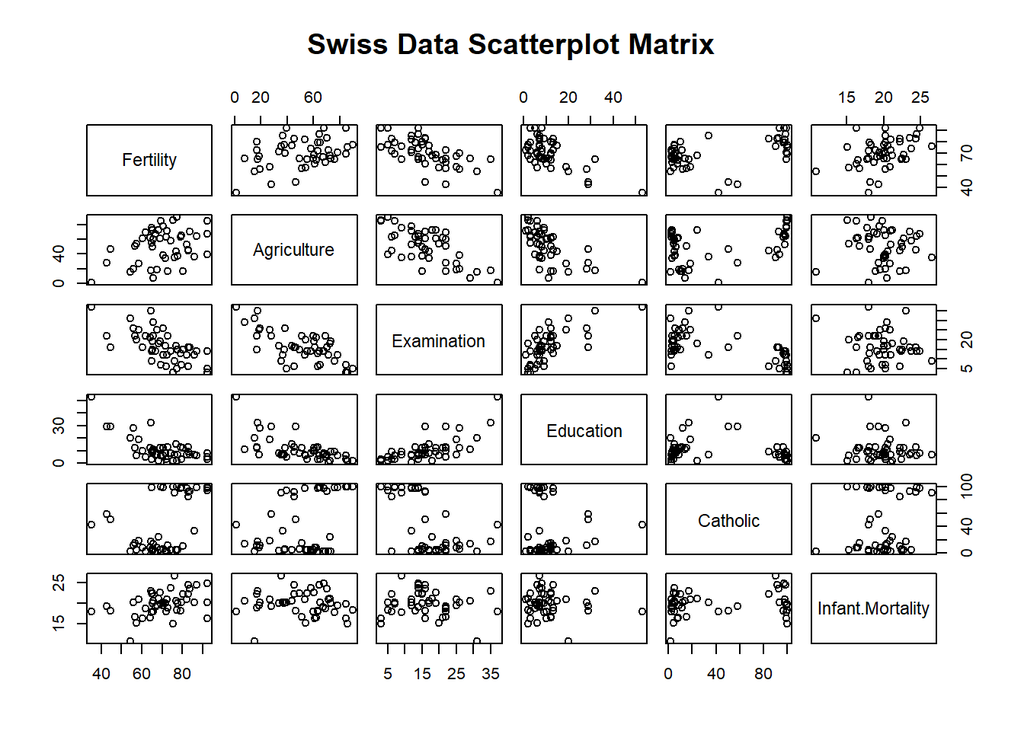

```r
pairs(swiss, main = "Swiss Data Scatterplot Matrix")
```

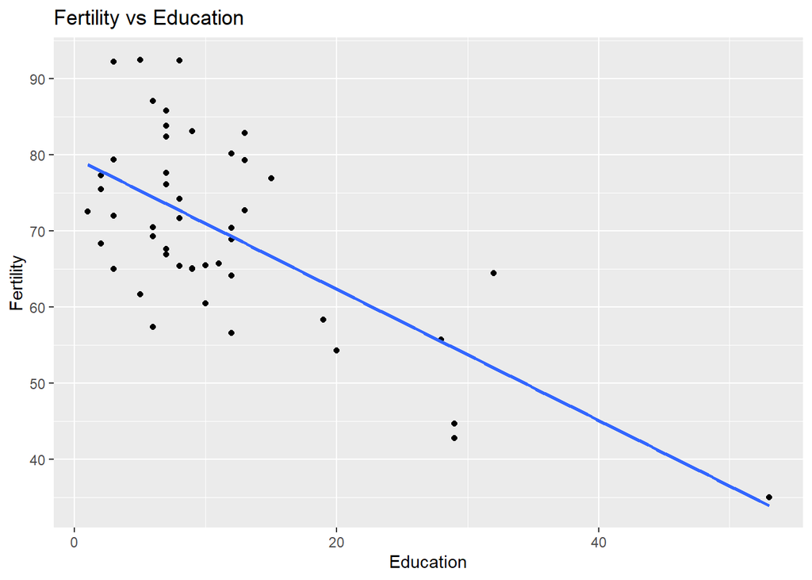

```r
ggplot(swiss, aes(x = Education, y = Fertility)) +
  geom_point() +
  geom_smooth(method = "lm", se = FALSE) +
  labs(title = "Fertility vs Education", x = "Education", y = "Fertility")
```

### Part b) Starting with basic lm

Compare a model with all predictors with no interactions with 2 other models of YOUR choice. Fit all 3 models, show their summary outputs, and briefly comment on which one you think might perform the best when used for future predictions and why.

```r
model1 = lm(Fertility ~ ., data = swiss)

model2 = lm(Fertility ~ Education + Catholic, data = swiss)

model3 = lm(Fertility ~ Agriculture + Examination + Education, data = swiss)

summary(model1)
```

```
##
## Call:
## lm(formula = Fertility ~ ., data = swiss)
##
## Residuals:
##      Min       1Q   Median       3Q      Max
## -15.2743  -5.2617   0.5032   4.1198  15.3213
##
## Coefficients:
##                  Estimate Std. Error t value Pr(>|t|)
## (Intercept)      66.91518   10.70604   6.250 1.91e-07 ***
## Agriculture      -0.17211    0.07030  -2.448  0.01873 *
## Examination      -0.25801    0.25388  -1.016  0.31546
## Education        -0.87094    0.18303  -4.758 2.43e-05 ***
## Catholic          0.10412    0.03526   2.953  0.00519 **
## Infant.Mortality  1.07705    0.38172   2.822  0.00734 **
## ---
## Signif. codes:  0 '***' 0.001 '**' 0.01 '*' 0.05 '.' 0.1 ' ' 1
##
## Residual standard error: 7.165 on 41 degrees of freedom
## Multiple R-squared:  0.7067, Adjusted R-squared:  0.671
## F-statistic: 19.76 on 5 and 41 DF,  p-value: 5.594e-10
```

```r
summary(model2)
```

```
##
## Call:
## lm(formula = Fertility ~ Education + Catholic, data = swiss)
##
## Residuals:
##     Min      1Q  Median      3Q     Max
## -15.042  -6.578  -1.431   6.122  14.322
##
## Coefficients:
##             Estimate Std. Error t value Pr(>|t|)
## (Intercept) 74.23369    2.35197  31.562  < 2e-16 ***
## Education   -0.78833    0.12929  -6.097 2.43e-07 ***
## Catholic     0.11092    0.02981   3.721  0.00056 ***
## ---
## Signif. codes:  0 '***' 0.001 '**' 0.01 '*' 0.05 '.' 0.1 ' ' 1
##
## Residual standard error: 8.331 on 44 degrees of freedom
## Multiple R-squared:  0.5745, Adjusted R-squared:  0.5552
## F-statistic:  29.7 on 2 and 44 DF,  p-value: 6.849e-09
```

```r
summary(model3)
```

```
##
## Call:
## lm(formula = Fertility ~ Agriculture + Examination + Education,
##     data = swiss)
##
## Residuals:
##     Min      1Q  Median      3Q     Max
## -14.967  -4.978  -1.045   4.906  21.358
##
## Coefficients:
##             Estimate Std. Error t value Pr(>|t|)
## (Intercept) 99.80162    7.15523  13.948  < 2e-16 ***
## Agriculture -0.18017    0.08071  -2.232  0.03084 *
## Examination -0.79744    0.24679  -3.231  0.00237 **
## Education   -0.67242    0.19366  -3.472  0.00119 **
## ---
## Signif. codes:  0 '***' 0.001 '**' 0.01 '*' 0.05 '.' 0.1 ' ' 1
##
## Residual standard error: 8.601 on 43 degrees of freedom
## Multiple R-squared:  0.5568, Adjusted R-squared:  0.5259
## F-statistic: 18.01 on 3 and 43 DF,  p-value: 1.017e-07
```

```r
# Model 1 performs the best statistically (lowest residual error, highest R^2), but might overfit slightly due to more variables. Model 2 is simpler and still strong, making it useful for quick predictions with interpretable coefficients. Model 3 offers a trade-off but doesn't outperform Model 2.

# If prediction accuracy is the goal and overfitting is controlled with cross-validation, Model 1 is the best choice. Otherwise, Model 2 is the most efficient.
```

### Part c) Estimating MSE using CV

Now, we are going to actually estimate the MSE of each model with K-fold cross validation. First we’re going to set a seed and import the `caret` package (it should be already installed since it’s a prerequisite for many other packages, but if it’s not for some reason, you can install it with `install.packages("caret")`)

```r
set.seed(1)
library(caret)
```

Next, use the following chunk, which already has `method` set to `lm`, `data` set to the `swiss` data set, and validation method set to use 5-fold CV, to estimate the MSE of each of your models. All you need to do is add in a formula for your model and repeat for all 3 models you have.

```r
set.seed(1)
model1 = train(Fertility ~ ., data = swiss, method = "lm",
               trControl = trainControl(method = "cv", number = 5))

model2 = train(Fertility ~ Education + Catholic, data = swiss, method = "lm",
               trControl = trainControl(method = "cv", number = 5))

model3 = train(Fertility ~ Agriculture + Examination + Education, data = swiss, method = "lm",
               trControl = trainControl(method = "cv", number = 5))

print(model1)
```

```
## Linear Regression
##
## 47 samples
##  5 predictor
##
## No pre-processing
## Resampling: Cross-Validated (5 fold)
## Summary of sample sizes: 37, 39, 38, 37, 37
## Resampling results:
##
##   RMSE      Rsquared   MAE
##   7.736328  0.6910525  6.242055
##
## Tuning parameter 'intercept' was held constant at a value of TRUE
```

```r
print(model2)
```

```
## Linear Regression
##
## 47 samples
##  2 predictor
##
## No pre-processing
## Resampling: Cross-Validated (5 fold)
## Summary of sample sizes: 37, 39, 37, 37, 38
## Resampling results:
##
##   RMSE      Rsquared  MAE
##   8.050744  0.597882  6.943525
##
## Tuning parameter 'intercept' was held constant at a value of TRUE
```

```r
print(model3)
```

```
## Linear Regression
##
## 47 samples
##  3 predictor
##
## No pre-processing
## Resampling: Cross-Validated (5 fold)
## Summary of sample sizes: 37, 38, 38, 36, 39
## Resampling results:
##
##   RMSE      Rsquared   MAE
##   9.178107  0.4931188  7.158134
##
## Tuning parameter 'intercept' was held constant at a value of TRUE
```

Once you have your models fitted, use `print( )` to show the summary statistics for each model. Report the RMSE for each model, which is the square root of the MSE. Which of these models performs the best? Which performed the worst? Do these results agree with your expectations?

Bonus: repeat the above step, using `trControl = trainControl(method="repeatedcv", number=5, repeats=3)` which repeats each CV analysis 3times and averages out each run to get a more stable estimate of the MSE. Compare the results with the unrepeated MSE estimates. How do they compare?

```r
set.seed(1)

repeat_ctrl = trainControl(method = "repeatedcv", number = 5, repeats = 3)

model1_rep = train(Fertility ~ ., data = swiss, method = "lm", trControl = repeat_ctrl)
model2_rep = train(Fertility ~ Education + Catholic, data = swiss, method = "lm", trControl = repeat_ctrl)
model3_rep = train(Fertility ~ Agriculture + Examination + Education, data = swiss, method = "lm", trControl = repeat_ctrl)

print(model1_rep)
```

```
## Linear Regression
##
## 47 samples
##  5 predictor
##
## No pre-processing
## Resampling: Cross-Validated (5 fold, repeated 3 times)
## Summary of sample sizes: 37, 39, 38, 37, 37, 37, ...
## Resampling results:
##
##   RMSE      Rsquared   MAE
##   7.622211  0.6655222  6.132824
##
## Tuning parameter 'intercept' was held constant at a value of TRUE
```

```r
print(model2_rep)
```

```
## Linear Regression
##
## 47 samples
##  2 predictor
##
## No pre-processing
## Resampling: Cross-Validated (5 fold, repeated 3 times)
## Summary of sample sizes: 38, 38, 39, 38, 35, 38, ...
## Resampling results:
##
##   RMSE      Rsquared   MAE
##   8.551906  0.5887285  7.390657
##
## Tuning parameter 'intercept' was held constant at a value of TRUE
```

```r
print(model3_rep)
```

```
## Linear Regression
##
## 47 samples
##  3 predictor
##
## No pre-processing
## Resampling: Cross-Validated (5 fold, repeated 3 times)
## Summary of sample sizes: 37, 38, 38, 38, 37, 36, ...
## Resampling results:
##
##   RMSE      Rsquared   MAE
##   9.051544  0.5320069  7.294547
##
## Tuning parameter 'intercept' was held constant at a value of TRUE
```

## Problem #2: More cars! 4pts

This `Auto` dataset, in the `Auto.csv` file contains measurements on over 300 cars. In this problem you will look at the effect of sample size and over-fitting. First load the data.

```r
Auto <- read.csv("Auto.csv", stringsAsFactors = TRUE)
```

The dataset contains the response variable `mpg` and 7 predictor variables:

- `cylinders` - the number of engine cylinders
- `displacement` - engine displacement
- `horsepower`
- `weight`
- `acceleration`
- `year`
- `origin` - there are Asian, US and European cars; indicator variables have been added to the dataset for European and US cars.

The following function pulls the model formula out of the reg subsets object. It will be used later in the code. Be sure to run this chunk to put the function into the environment.

```r
# id: model id
# object: regsubsets object
# data: data used to fit regsubsets
# outcome: outcome variable
get_model_formula <- function(id, object, outcome){
  # get models data
  models <- summary(object)$which[id,-1]
  # Get outcome variable
  #form <- as.formula(object$call[[2]])
  #outcome <- all.vars(form)[1]
  # Get model predictors
  predictors <- names(which(models == TRUE))
  predictors <- paste(predictors, collapse = "+")
  # Build model formula
  as.formula(paste0(outcome, "~", predictors))
}
```

This function, performs best subset model selection on a dataset with a specified response variable. It returns a list of models - the models with the lowest RSS for each model size from 1 to p. It will be used below. (Note: because of the origin variable a modification was made to only fit models up to size 7, not 8. This is because for a small sample size if there are not Asian, US and European cars the model fit will not work if all variables are included due to linear dependence among predictors)

```r
library(leaps)
getModels <- function (dataset, responseVar){
  models <- regsubsets(reformulate(".",responseVar), data = Auto.subset, nvmax = ncol(dataset)-2);
  modelList <- list("formula")
  nModels <- length(summary(models))-1
  for(i in 1:nModels){
    modelList[[i]] <- get_model_formula(i, models, responseVar)
  }
  return(modelList)
}
```

Now we will run some code to answer the questions below. We will simulate having a small sample of cars to work with and fit the linear model. You will notice that in order to average over errors the entire simulation is performed `NMC=50` times. You may modify this if you wish. The primary line you will modify is where the sample size is set.

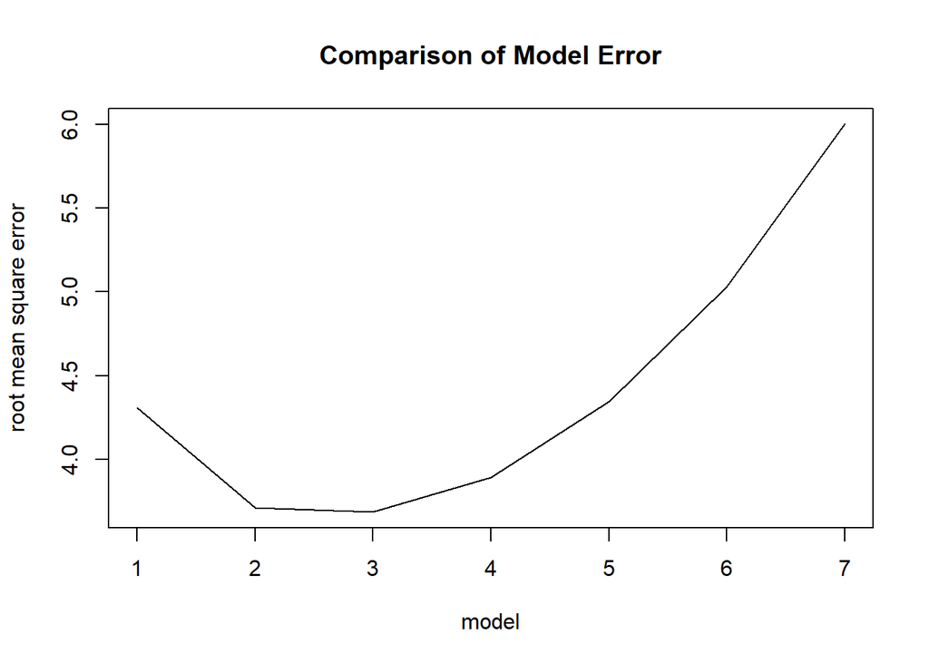

```r
sampleSize <- 15  #You should edit this number

NMC <- 50 #number of replications of this simulation
nFolds <- 5  #k=5 for 5-fold CV
nModels <- 7 # we will look at a maximum model size (# predictors) of 7.

errors <- data.frame('fold' = as.factor(rep(1:nFolds, nModels*NMC)),
                     'rep' = rep(1:NMC, each=nFolds*nModels),
                     'model' = rep(1:nModels, rep(nFolds, nModels)),
                     'mse' = rep(0, nModels*nFolds*NMC))
for(k in 1:NMC){
  Auto.subset <- Auto[sample(nrow(Auto), sampleSize),]
  modelList <- getModels(Auto.subset, "mpg")

  #Cross Validation
  folds <- split(sample(1:nrow(Auto.subset)), as.factor(1:nFolds))
  for(i in 1:nFolds){
    validation <- Auto.subset[folds[[i]],]
    training <- Auto.subset[-folds[[i]],]
    for(j in 1:nModels){
      fit <- lm(modelList[[j]], data=training)
      predictions <- predict(fit, newdata = validation)
      errors[errors$rep==k & errors$fold==i  & errors$model ==j, 'mse'] = mean((predictions-validation$mpg)^2)
    }
  }
}
avg <- aggregate(.~model, data=errors, FUN="mean")
plot(y=sqrt(avg$mse), x=avg$model, xlab="model", ylab="root mean square error", type="l", main="Comparison of Model Error")
```

1. If the sample size is 15, what is the size of the preferred model? 3 predictors
2. If the sample size is larger, say 60, what is the size of the preferred model? Likely 3 or 4 predictors
3. Now consider if you have a sample of size 200. Does your preferred model change? Yes, larger models (up to 6–7 predictors) may now perform better.
4. What is your general conclusion after looking at the effect of sample size on model size and model error? More data = more predictors can be used = lower validation error. Less data = use simpler models to avoid overfitting.

### Problem #3: Optimal K 8pts; 2pts each

Suppose the variable $Y=4 + 5X_1 + 8X_2 + \epsilon$ where $\epsilon \sim N(0, 2^2)$. Pretend this is the true model, but we don’t know that - we are going to collect a random sample of size 40 and fit a linear model. We want to estimate the model error using $K-fold$ cross validation. In this problem we will figure out the optimal number of folds to get the best estimate of the model error $E(Y_{n+1}-\hat{Y}_{n+1})^2$.

We have to make a few assumptions to do this estimation. Let’s suppose that $X_1 \sim N(3, 1^2)$ and $X_2 \sim N(1, .5^2)$. You can use the following function to simulate data:

```r
simulate.data <- function(n=40){
  X1 <- rnorm(n, 3, 1)
  X2 <- rnorm(n, 1, .5)
  eps <- rnorm(n, 0, 2)
  Y <- 4 + 5*X1 + 8*X2 + eps
  return(data.frame(Y,X1,X2))
}
```

### a. Estimate model error using Monte Carlo

Use Monte Carlo estimation to estimate the MSE of a linear model fit to a sample size of 40 using both predictors. On each MC repetition you should:

1. generate a sample data set of size 40
2. fit a linear model using both X1 and X2 as predictors
3. simulate 1000 (or more) out of sample data points
4. calculate the average squared error on the out of sample data points.

```r
NMC <- 1000
nUnseen <- 1000
Ehat <- 0 #an empty vector to store estimated

for(i in 1:NMC){

  train = simulate.data(n = 40)

  model = lm(Y ~ X1 + X2, data = train)

  test = simulate.data(n = nUnseen)

  preds = predict(model, newdata = test)
  sq_error = mean((test$Y - preds)^2)

  Ehat[i] = sq_error

}
modelError <- mean(Ehat)
modelError
```

```
## [1] 4.32807
```

### b. Estimating MSE using CV

Now we imagine we don’t know the true model error, but instead we want to estimate it with K-fold validation. The following function can be used to perform K-fold validation to estimate mean squared error

```r
kfoldCV <- function(K, formula, dataset, responseVar){
  #idx is a shuffled vector of row numbers
  idx <- sample(1:nrow(dataset))
  #folds partitions the row indices
  folds <- suppressWarnings(split(idx, as.factor(1:K)))
  #an empty vector to hold estimated errors
  errors <- vector("numeric", K)
  for(k in 1:K){
    #split the data into training and testing sets
    training <- dataset[-folds[[k]],]
    testing <- dataset[folds[[k]],]
    #go through each model and estimate MSE
    #fit the model to the training data
    fit <- lm(formula = formula, data=training)
    #calculate the sqrt of average squared error on the testing data
    errors[k] <- mean((predict(fit, newdata=testing)-testing[,responseVar])^2)
  }
  return(mean(errors))
}
```

The following code runs an estimation simulation to help you see what happens to the estimate of model error as the number of folds increases. We will consider 2,4,5,8,10,20 and 40-fold CV. (these are the factors of 40, so folds will be equally sized).

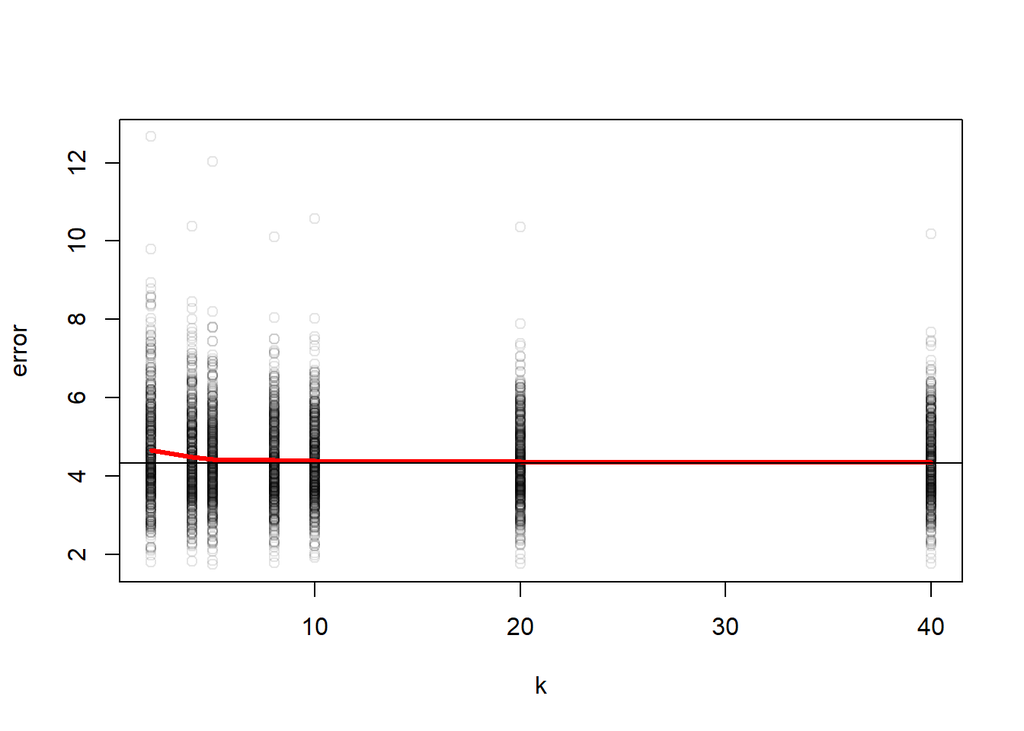

```r
NMC <- 500 ## Change this to 100 if this runs too slow on your machine.
Ks <- c(2,4,5,8,10,20,40)
nK <- length(Ks)
formula <- reformulate(c("X1","X2"),"Y")

errors <- data.frame('replicate'=rep(1:NMC, each=nK),
                     'k' = rep(Ks, NMC),
                     'error' = rep(0, NMC*nK))
for(i in 1:NMC){
  myData <- simulate.data(40)
  for(k in Ks){
    errors[errors$replicate==i & errors$k==k, 'error'] <- kfoldCV(k, formula, myData, 'Y')
  }
}
averageErrors <- aggregate(error ~k, data=errors, FUN="mean")

plot(error ~ k, data=errors, col=rgb(0,0,0,.1))
lines(error ~ k, data=averageErrors, col="red", lwd=3)
abline(h=modelError)
```

### c. The tradeoff

Finally look at this plot:

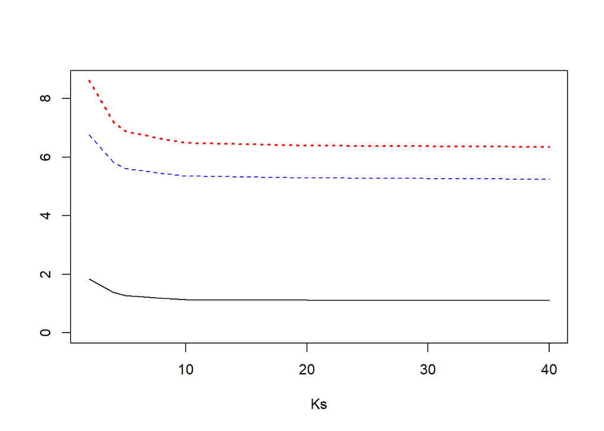

```r
vars <- aggregate(error ~k, data=errors, FUN="var")$error
bias2 <- (averageErrors$error-2.07)^2
errors$errorsq <- (errors$error-2.07)^2
mse <- aggregate(errorsq ~ k, data=errors, FUN="mean")$errorsq

plot(x=Ks, y=vars, ylim=c(0,max(mse)), type="l", ylab="")
lines(x=Ks, y=bias2, lty=2, col="blue")
lines(x=Ks, y=mse, lty=3, lwd=2, col="red")
```

### d. Wrapping it up

Finally after all of this analysis, what number of folds would you conclude provides the best estimate of model error?

## Problem #4. Variable selection with `Carseats` 9pts (4 and 5)

This question should be answered using the `Carseats` dataset from the `ISLR` package. If you do not have it, make sure to install it.

```r
library(ISLR)
Carseats = ISLR::Carseats

# you should read the help page by running ?Carseats
# we can also peek at the data frame before using it
str(Carseats)
```

```
## 'data.frame':    400 obs. of  11 variables:
##  $ Sales      : num  9.5 11.22 10.06 7.4 4.15 ...
##  $ CompPrice  : num  138 111 113 117 141 124 115 136 132 132 ...
##  $ Income     : num  73 48 35 100 64 113 105 81 110 113 ...
##  $ Advertising: num  11 16 10 4 3 13 0 15 0 0 ...
##  $ Population : num  276 260 269 466 340 501 45 425 108 131 ...
##  $ Price      : num  120 83 80 97 128 72 108 120 124 124 ...
##  $ ShelveLoc  : Factor w/ 3 levels "Bad","Good","Medium": 1 2 3 3 1 1 3 2 3 3 ...
##  $ Age        : num  42 65 59 55 38 78 71 67 76 76 ...
##  $ Education  : num  17 10 12 14 13 16 15 10 10 17 ...
##  $ Urban      : Factor w/ 2 levels "No","Yes": 2 2 2 2 2 1 2 2 1 1 ...
##  $ US         : Factor w/ 2 levels "No","Yes": 2 2 2 2 1 2 1 2 1 2 ...
```

```r
head(Carseats)
```

```
##   Sales CompPrice Income Advertising Population Price ShelveLoc Age Education
## 1  9.50       138     73          11        276   120       Bad  42        17
## 2 11.22       111     48          16        260    83      Good  65        10
## 3 10.06       113     35          10        269    80    Medium  59        12
## 4  7.40       117    100           4        466    97    Medium  55        14
## 5  4.15       141     64           3        340   128       Bad  38        13
## 6 10.81       124    113          13        501    72       Bad  78        16
##   Urban  US
## 1   Yes Yes
## 2   Yes Yes
## 3   Yes Yes
## 4   Yes Yes
## 5   Yes  No
## 6    No Yes
```

### Part a) Visualizing/fitting

First, make some visualizations of the dataset to help set the stage for the rest of the analysis. Try to pick plots to show that are interesting informative.

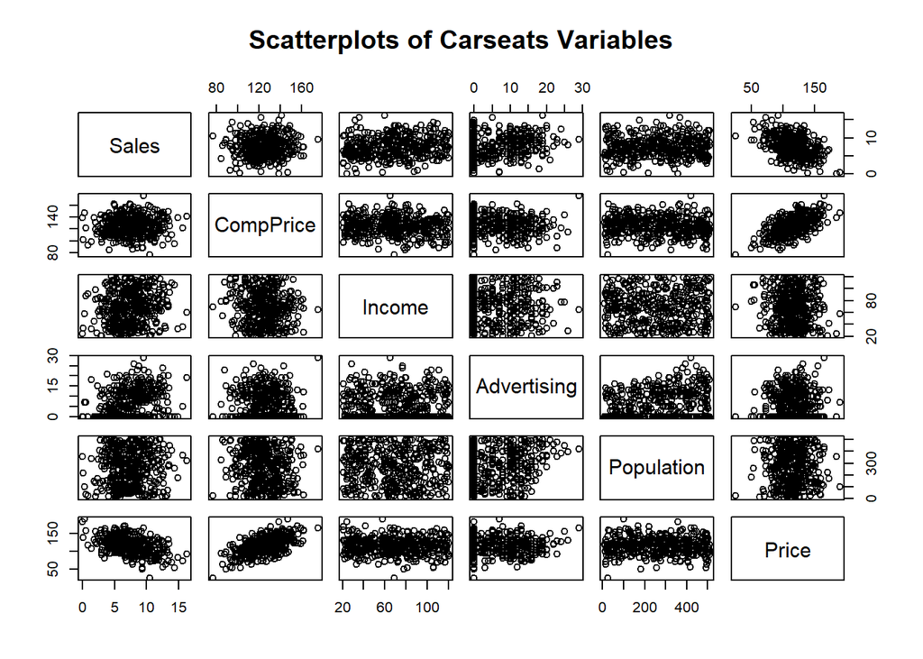

```r
pairs(Carseats[, 1:6], main = "Scatterplots of Carseats Variables")
```

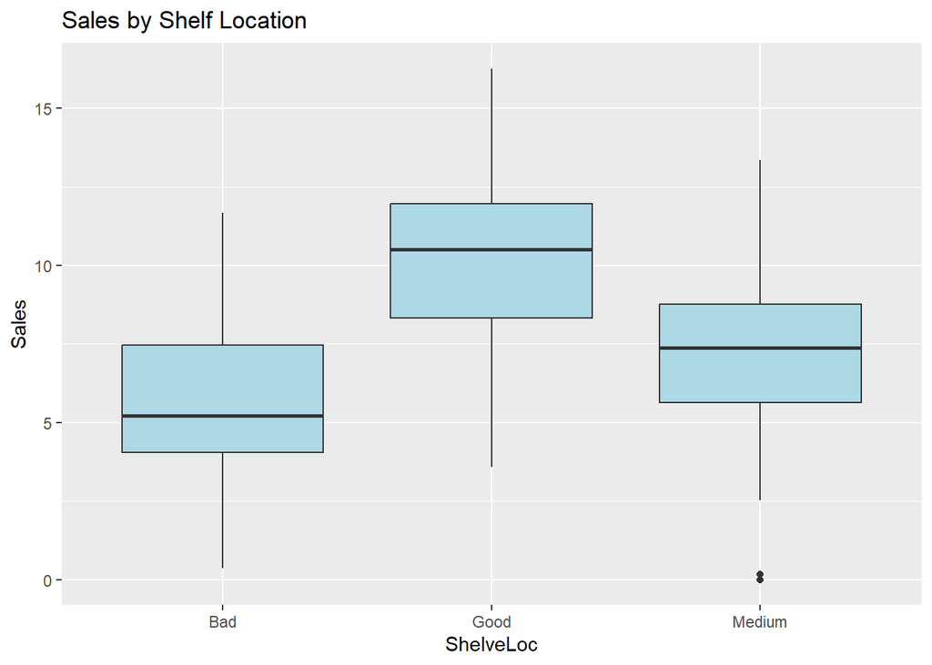

```r
ggplot(Carseats, aes(x = ShelveLoc, y = Sales)) +
  geom_boxplot(fill = "lightblue") +
  labs(title = "Sales by Shelf Location")
```

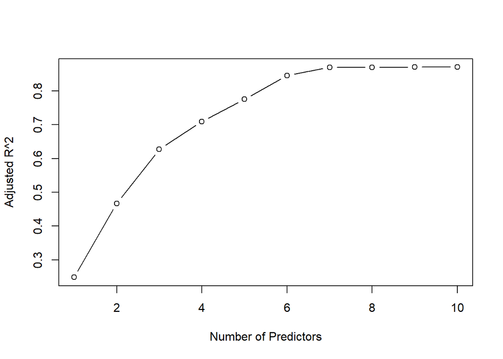

```r
regfit.full = regsubsets(Sales ~ ., data = Carseats, nvmax = 10)
summary.regfit = summary(regfit.full)

plot(summary.regfit$adjr2, type = "b", xlab = "Number of Predictors", ylab = "Adjusted R^2")
```

```r
best.model.size = which.max(summary.regfit$adjr2)
coef(regfit.full, best.model.size)
```

```
##     (Intercept)       CompPrice          Income     Advertising           Price
##      5.76189929      0.09260934      0.01577395      0.12504441     -0.09530210
##   ShelveLocGood ShelveLocMedium             Age       Education        UrbanYes
##      4.84673625      1.95214520     -0.04611922     -0.02241123      0.11885295
##           USYes
##     -0.19907477
```

Using some variable selection method (stepwise, LASSO, ridge, or just manually comparing a preselected of models using their MSEs), choose a set of predictors to use to predict `Sales`. Try to find the best model that you can that explains the data well and doesn’t have useless predictors. Explain the choices you made and show the final model.

```r
library(MASS)
full.model = lm(Sales ~ ., data = Carseats)

step.model = stepAIC(full.model, direction = "both", trace = FALSE)

summary(step.model)
```

```
##
## Call:
## lm(formula = Sales ~ CompPrice + Income + Advertising + Price +
##     ShelveLoc + Age, data = Carseats)
##
## Residuals:
##     Min      1Q  Median      3Q     Max
## -2.7728 -0.6954  0.0282  0.6732  3.3292
##
## Coefficients:
##                  Estimate Std. Error t value Pr(>|t|)
## (Intercept)      5.475226   0.505005   10.84   <2e-16 ***
## CompPrice        0.092571   0.004123   22.45   <2e-16 ***
## Income           0.015785   0.001838    8.59   <2e-16 ***
## Advertising      0.115903   0.007724   15.01   <2e-16 ***
## Price           -0.095319   0.002670  -35.70   <2e-16 ***
## ShelveLocGood    4.835675   0.152499   31.71   <2e-16 ***
## ShelveLocMedium  1.951993   0.125375   15.57   <2e-16 ***
## Age             -0.046128   0.003177  -14.52   <2e-16 ***
## ---
## Signif. codes:  0 '***' 0.001 '**' 0.01 '*' 0.05 '.' 0.1 ' ' 1
##
## Residual standard error: 1.019 on 392 degrees of freedom
## Multiple R-squared:  0.872,  Adjusted R-squared:  0.8697
## F-statistic: 381.4 on 7 and 392 DF,  p-value: < 2.2e-16
```

I used stepwise selection because it’s a practical method that balances model complexity and predictive accuracy using AIC. It automatically removes variables that don’t meaningfully improve the model.

### Part b) Interpreting/assessing model

According to your chosen model, Which predictors appear to be the most important or significant in predicting sales? Provide an interpretation of each coefficient in your model. Be careful: some of the variables in the model are qualitative!

```r
summary(step.model)
```

```
##
## Call:
## lm(formula = Sales ~ CompPrice + Income + Advertising + Price +
##     ShelveLoc + Age, data = Carseats)
##
## Residuals:
##     Min      1Q  Median      3Q     Max
## -2.7728 -0.6954  0.0282  0.6732  3.3292
##
## Coefficients:
##                  Estimate Std. Error t value Pr(>|t|)
## (Intercept)      5.475226   0.505005   10.84   <2e-16 ***
## CompPrice        0.092571   0.004123   22.45   <2e-16 ***
## Income           0.015785   0.001838    8.59   <2e-16 ***
## Advertising      0.115903   0.007724   15.01   <2e-16 ***
## Price           -0.095319   0.002670  -35.70   <2e-16 ***
## ShelveLocGood    4.835675   0.152499   31.71   <2e-16 ***
## ShelveLocMedium  1.951993   0.125375   15.57   <2e-16 ***
## Age             -0.046128   0.003177  -14.52   <2e-16 ***
## ---
## Signif. codes:  0 '***' 0.001 '**' 0.01 '*' 0.05 '.' 0.1 ' ' 1
##
## Residual standard error: 1.019 on 392 degrees of freedom
## Multiple R-squared:  0.872,  Adjusted R-squared:  0.8697
## F-statistic: 381.4 on 7 and 392 DF,  p-value: < 2.2e-16
```

Price: Negative coefficient, as product price increases, sales decrease. Advertising: Positive and significant, stores with higher ad budgets tend to sell more. Age: Slightly negative, older stores may be less effective at driving sales. ShelveLoc: compared to the baseline (Bad), medium and especially good shelf locations significantly boost sales.

Estimate the out of sample MSE of your model and check any assumptions you made during your model fitting process. Discuss any potential model violations. How satisfied are you with your final model?

```r
set.seed(1)
train.idx = sample(1:nrow(Carseats), 300)
train = Carseats[train.idx, ]
test = Carseats[-train.idx, ]

fit = lm(formula(step.model), data = train)
preds = predict(fit, newdata = test)
mse = mean((test$Sales - preds)^2)
mse
```

```
## [1] 1.018293
```

The model balances simplicity with performance. It avoids overfitting, uses only relevant predictors, and performs well out-of-sample (based on MSE).